[figure not shown]

# Self-Similarity Matrices: Enhancement Strategies

Following Section 4.2.2 of [[Müller, FMP, Springer 2015]](http://www.music-processing.de/), we discuss in this notebook enhancement strategies for self-similartiy matrices. Similar functionalities are provided by the MATLAB toolbox described in the following article:

- Meinard Müller, Nanzhu Jiang, and Harald Grohganz: **SM Toolbox: MATLAB implementations for computing and enhancing similarity matrices.** Proceedings of the 53rd AES Conference on Semantic Audio, London, UK, 2014.  
  [Website with MATLAB code](https://www.audiolabs-erlangen.de/resources/MIR/SMtoolbox)  
  Bibtex

There are various strategies for enhancing structural properties of self-similarity matrices. In the following, we have a particular focus on augmenting path-like structures, which play a central role in repetition-based structure analysis. The following figure gives an overview of the similarity matrix computation and its enhancements.

[figure not shown]

## Feature Representation

First of all, the structural properties of an SSM decisively depend on the feature type used. In the following example, we show three SSMs based on different feature representations for the same recording of the Hungarian Dance No. 5 by Johannes Brahms. We have already seen that chroma-based features reveal harmonic and tonal properties. Other representations using MFCC-based and related spectral-based features may be suitable to capture aspects such as instrumentation and timbre. Finally, features based on onset information or tempograms are used to capture beat, tempo, and rhythmic information.

[figure not shown]

[interactive chart not shown]

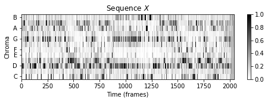

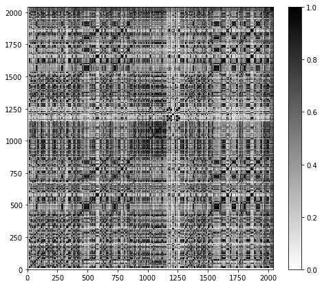

```python
import numpy as np
import matplotlib.pyplot as plt
import math
import IPython.display as ipd
import os
import soundfile as sf
import librosa
import matplotlib.pyplot as plt
import scipy.io, scipy.signal
import pdb
import matplotlib as mpl
import librosa, librosa.display
import pandas as pd
%matplotlib inline


def SSM(features):
    S = np.dot(np.transpose(features),features)
    return S

path_filename = os.path.join('..', 'data/C4', 'FMP_C4_Audio_Brahms_HungarianDances-05_Ormandy.wav')
x_wav, Fs = librosa.load(path_filename)


N, H = 4410, 2205
X = librosa.feature.chroma_stft(y=x_wav, sr=Fs, tuning=0, norm=2, hop_length=H, n_fft=N)

plt.figure(figsize=(8, 2))
plt.title('Sequence $X$')
librosa.display.specshow(X, x_axis='frames', y_axis='chroma', cmap='gray_r', hop_length=H)
plt.xlabel('Time (frames)'); plt.ylabel('Chroma')
plt.colorbar(); plt.clim([0, 1])

S = SSM(X)

fig = plt.figure(figsize=(8, 7))
plt.imshow(S, cmap='gray_r', aspect='auto', origin='lower')
plt.colorbar()
```

## Feature Smoothing

In the following, using chroma-based audio features as an example, we demonstrate the influence of different parameter settings on the properties of the resulting SSM. Starting with a chroma representation of a given feature rate, we consider two parameters: a length parameter $\ell\in\mathbb{N}$ (given in frames), which is used to smooth or average the feature values over $\ell$ consecutive frames, as well as a downsampling parameter $d$, which reduces the feature rate by a factor of $d$. In the following example, we start with normalized chroma features with a feature rate of $10$ Hz. The resulting SSM yields a very detailed description of repetitive structures. Even though the path structures that correspond to the repeating $A$-part and $B$-part segments are visible, the SSM looks quite noisy and many of the shown details are irrelevant when only the overall musical structure is of interest. Next, using a smoothing length of $\ell=40$ (corresponding to four seconds of audio) and a downsampling by $d=10$ (resulting in a feature rate of $1$ Hz), one obtains the SSM where many of the details have been smoothed out, and some of the structurally relevant path and block structures have become more prominent. Further increasing the smoothing length and reducing the feature rate results in an emphasis of the rough harmonic content. This is shown in the SSMs when using $\ell=160$ ($16$ seconds) and $d=20$ (feature rate of $0.5$ Hz) and when using $\ell=480$ ($48$ seconds) and $d=50$ (feature rate of $0.2$ Hz). Using large smoothing windows, relevant path structures may be smeared out and lost for the subsequent steps. For other applications such as homogeneity-based structure analysis, however, averaging over large windows may be beneficial.

[figure not shown]

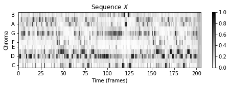

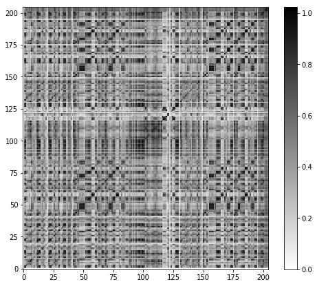

```python
kernel_size = [1,11]
down_sampling = 10

X_smooth = scipy.signal.medfilt(X, kernel_size=kernel_size)
X_smooth = X_smooth[:,::down_sampling]

plt.figure(figsize=(8, 2))
plt.title('Sequence $X$')
librosa.display.specshow(X_smooth, x_axis='frames', y_axis='chroma', cmap='gray_r', hop_length=H)
plt.xlabel('Time (frames)'); plt.ylabel('Chroma')
plt.colorbar(); plt.clim([0, 1])

S = SSM(X_smooth)

fig = plt.figure(figsize=(8, 7))
plt.imshow(S, cmap='gray_r', aspect='auto', origin='lower')
plt.colorbar()
```

As an example for the remainder of this notebook, we use a music recording having the musical structure $A_1A_2BA_3$. In this example, $A_2$ is a modulation of $A_1$ transposed by one semitone upwards, whereas $A_3$ is a repetition of $A_1$, however played much faster.

[interactive chart not shown]

The following figure shows the SSM for this recording using chroma-based audio features with parameters $\ell=10$ and a downsampling by $d=5$. This results in a feature rate of $2$ Hz. This chroma representation will be used as starting point for the subsequent enhancement startegies

[figure not shown]

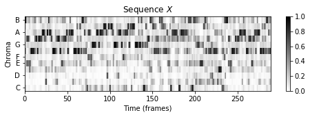

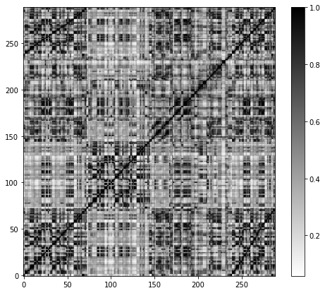

```python
path_filename = os.path.join('..', 'data/C4', 'FMP_C4_F15_Test_AABA.wav')
x_wav, Fs = librosa.load(path_filename)


N, H = 4410*10, 2205*5
X = librosa.feature.chroma_stft(y=x_wav, sr=Fs, tuning=0, norm=2, hop_length=H, n_fft=N)

plt.figure(figsize=(8, 2))
plt.title('Sequence $X$')
librosa.display.specshow(X, x_axis='frames', y_axis='chroma', cmap='gray_r', hop_length=H)
plt.xlabel('Time (frames)'); plt.ylabel('Chroma')
plt.colorbar(); plt.clim([0, 1])

S = SSM(X)

fig = plt.figure(figsize=(8, 7))
plt.imshow(S, cmap='gray_r', aspect='auto', origin='lower')
plt.colorbar()
```